# EDA

Zoltar-MX

27/11/2020

[figure not shown]

We will use Hex colors of Grupo Modelo

# Descriptive Statistics

### First of all we need to import our data and attach it to facilitate our code

```r
# importing data
library(ggplot2)
library(readr)
ubicaciones <- read_csv("ubicaciones.csv")
attach(ubicaciones)
```

### It’s important to look at the structure of our data set to see what types of variables we are working with

```r
# Obtaining a first approach to data
str(ubicaciones)
```

```
## tibble [3,625 × 6] (S3: spec_tbl_df/tbl_df/tbl/data.frame)
##  $ Id_Cliente : num [1:3625] 1 2 3 4 5 6 7 8 9 10 ...
##  $ id_Agencia : chr [1:3625] "A1" "A1" "A1" "A1" ...
##  $ Frecuencia : num [1:3625] 1 1 1 3 1 1 1 1 1 1 ...
##  $ Vol_Entrega: num [1:3625] 2 17 2 15 2 19 6 20 15 10 ...
##  $ lat        : num [1:3625] 20.5 20.5 20.5 20.5 20.5 ...
##  $ lon        : num [1:3625] -98.2 -98.2 -98.2 -98.2 -98.2 ...
##  - attr(*, "spec")=
##   .. cols(
##   ..   Id_Cliente = col_double(),
##   ..   id_Agencia = col_character(),
##   ..   Frecuencia = col_double(),
##   ..   Vol_Entrega = col_double(),
##   ..   lat = col_double(),
##   ..   lon = col_double()
##   .. )
```

### For convenience we are going to work mainly with ‘Frecuencia’ that has three different values and ‘Vol_Entrega’, lets see the central tendency measures, quartiles, maximum, minimum and standard deviation of these columns from our dataset

```r
# summary of Frecuencia and Vol_Entrega
summary(Vol_Entrega)
```

```
##    Min. 1st Qu.  Median    Mean 3rd Qu.    Max.
##     0.0     2.0     6.0    13.2    15.0   175.0
```

```r
summary(Frecuencia)
```

```
##    Min. 1st Qu.  Median    Mean 3rd Qu.    Max.
##   1.000   1.000   1.000   1.097   1.000   3.000
```

```r
# std
sd(Vol_Entrega)
```

```
## [1] 20.15825
```

# Plots

### In order to understand better our problem, it’s important to make some graphics

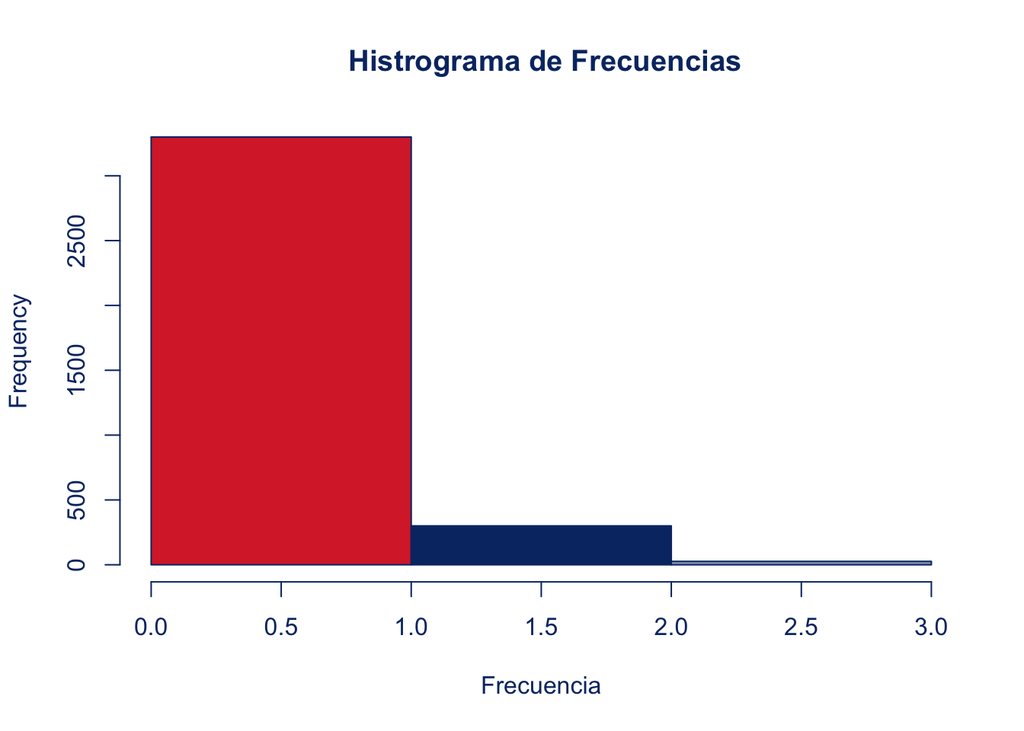

```r
# making histogram
par(bg = 'white',fg = '#083372', col.axis = "#083372", col.lab = "#083372", col.main = "#083372")
hist(Frecuencia,breaks = c(0:3), col = c("#d92d34","#083372","#97a6be"), main = " Histrograma de Frecuencias")
```

### This histogram didn’t tell us so much, just that we have three posible frequencies where freq. 1 is more used by far.

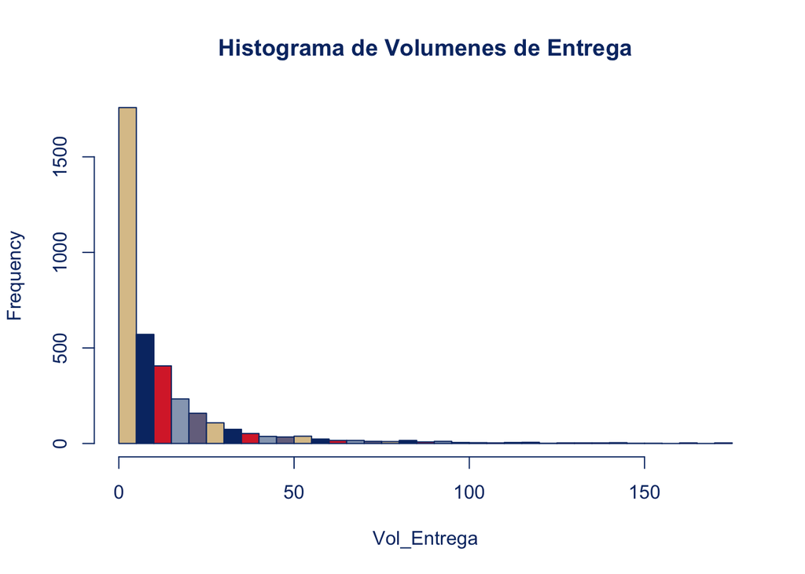

```r
par(bg = 'white',fg = '#083372', col.axis = "#083372", col.lab = "#083372", col.main = "#083372")
hist(Vol_Entrega, freq = T, breaks =25, main = "Histograma de Volumenes de Entrega", col = c("#dcc498","#083372","#d92d34","#97a6be","#76708d"))
```

### The histogram of delivery volume tells us that most of the deliveries are of a small volume, the mean and median above could confirm this, but we also have some deliveries that are above 150, that maybe those values could be treated as outliers.

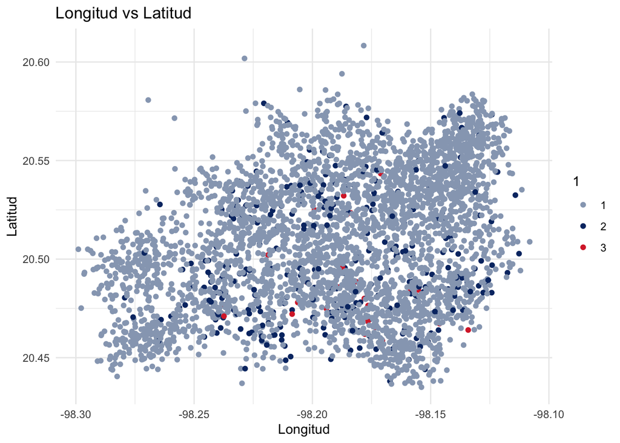

```r
ggplot(ubicaciones, aes(y=lat, x= lon, colour = as.character(Frecuencia))) + geom_point()+labs(title="Longitud vs Latitud",x="Longitud", y = "Latitud", colour=as.character(Frecuencia))+ scale_fill_discrete(name="Frecuencia")+scale_colour_manual(values=c("#97a6be","#083372","#d92d34","#76708d"))+theme_minimal()
```

### For this graph, it was plotted the ‘lon vs lat’ to see the distributions of our points, and coloured by frequency, most of the values for the three frequencies doesn’t seem to follow a function of some type, they seem dispersed.

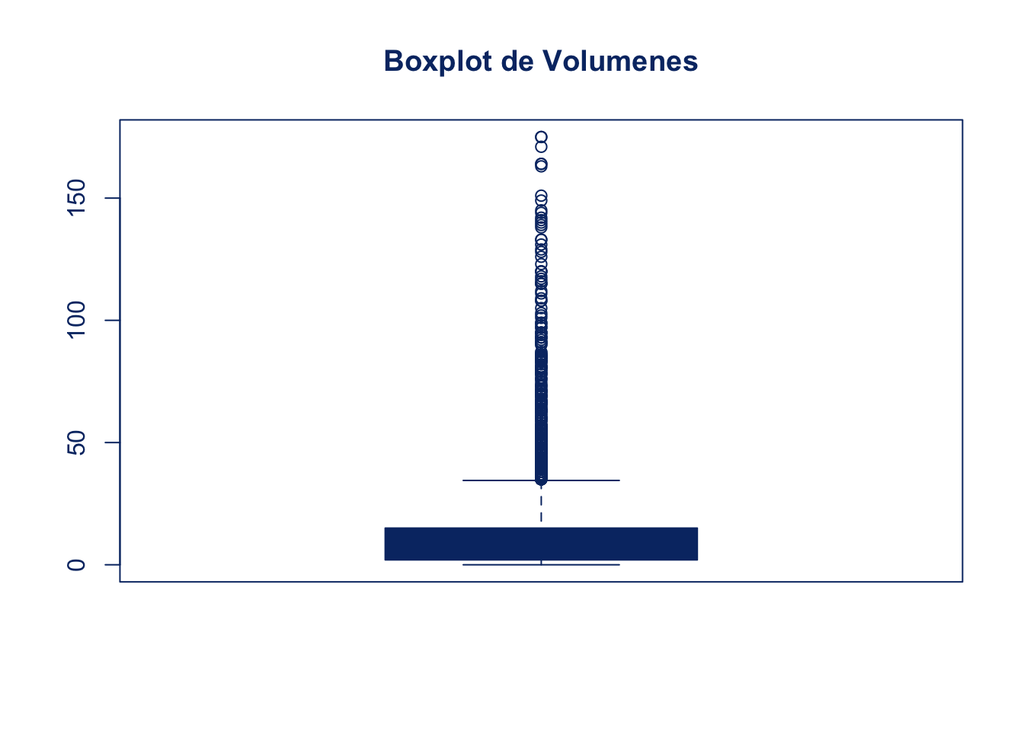

```r
# boxplot of Volume
par(bg = 'white',fg = '#083372', col.axis = "#083372", col.lab = "#083372", col.main = "#083372")
boxplot(Vol_Entrega, freq = T, col = "#083372", main = "Boxplot de Volumenes")
```

### The boxplot of the volume only shows us that we do have a lot of outliers, that goes from approx. 30 to 175.

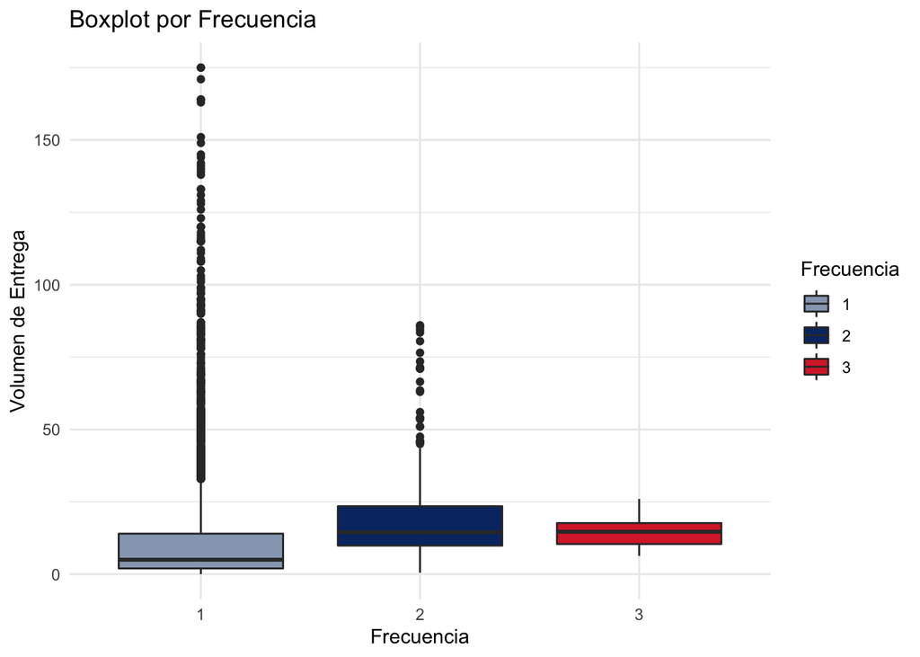

```r
ggplot(ubicaciones, aes(x=as.character(Frecuencia), y=Vol_Entrega, fill=as.character(Frecuencia))) + geom_boxplot()+labs(title="Boxplot por Frecuencia",x="Frecuencia", y = "Volumen de Entrega")+scale_fill_manual(values=c("#97a6be","#083372","#d92d34","#76708d"), name = "Frecuencia")+theme_minimal()
```

### Making also a boxplot but for every frequency we could see that when we increase it, we have a better distributed sample and least outliers.

# removing outliers and non important data

We made two functions for eliminate outliers:

```r
# function for remove outliers
outliersVolume <- function(column){
  iqr <- as.numeric(quantile(column, 0.75) - quantile(column, 0.25))
  lowLimit <- as.numeric(quantile(column, 0.25))
  highLimit <- as.numeric(quantile(column, 0.75) + 1.5*iqr)
  column <- column[column >= lowLimit & column <= highLimit & column !=0]
  column
}

outliersFreq <- function(freq){
  freq <- freq[freq >= 1 & freq <= 6]
}
```

### For the delivery volume outlier eliminator function, as we don’t seem to have outliers in the bottom part of our sample, we are going to have the values that are more than cero and are above the first quartile, and the limit above would be the superior arm of the boxplot.

### For the outliers frequency it’s just a function to eliminate all those outliers that are below one or above six.

### This functions won’t be utilized to eliminate outliers on the EDA but they could me helpfull when we apply some algorithms.

# EDA by each frequency

### In this section we are going to make another exploratory analysis of the delivery volume but for each frequency.

### We make this function to show the size of every sample, the central tendency measures and the standard deviation.

```r
Vol_Entrega_num <- function(vol_Entrega_num){
  print("Size:")
  print(length(vol_Entrega_num))
  print("Central tendency measures:")
  print(summary(vol_Entrega_num))
  print("Standard deviation:")
  sd(vol_Entrega_num)
}
```

## Frequency = 1

```
## [1] "Size:"
## [1] 3299
## [1] "Central tendency measures:"
##    Min. 1st Qu.  Median    Mean 3rd Qu.    Max.
##    0.00    2.00    5.00   12.62   14.00  175.00
## [1] "Standard deviation:"
```

```
## [1] 20.45337
```

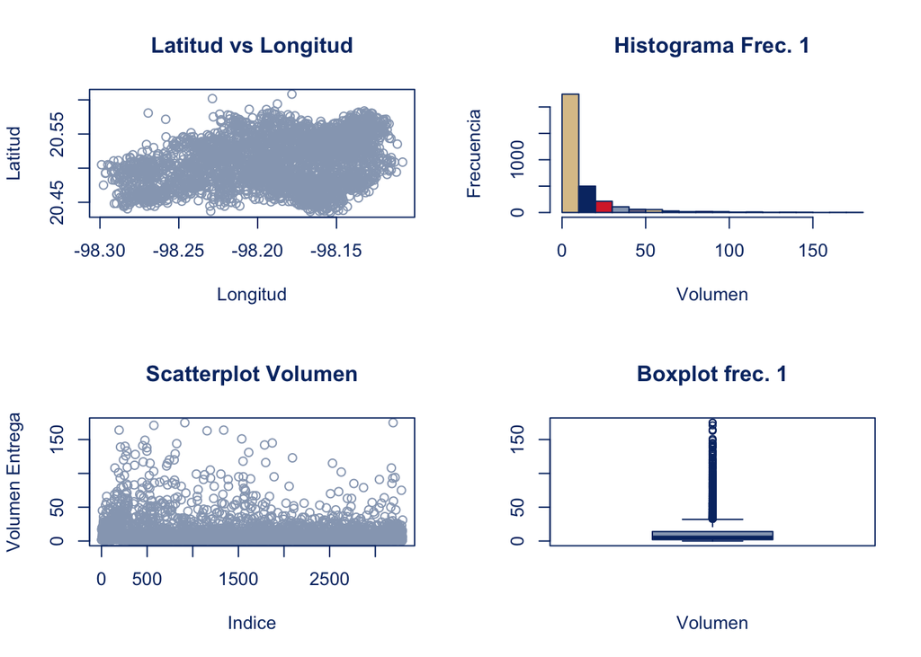

### We could see that this sample behaves almost as the original sample because the size is enourmous compared to the other two frequencies, we have a big std because of the outliers, and our median delivery volume is five. The plots could have the same analysis as the original sample, it’s important to watch that the sample has a lot of 0 delivery volume values.

### Frequency = 2

```
## [1] "Size:"
## [1] 300
## [1] "Central tendency measures:"
##    Min. 1st Qu.  Median    Mean 3rd Qu.    Max.
##   0.500   9.875  14.500  19.385  23.500  86.000
## [1] "Standard deviation:"
```

```
## [1] 16.3374
```

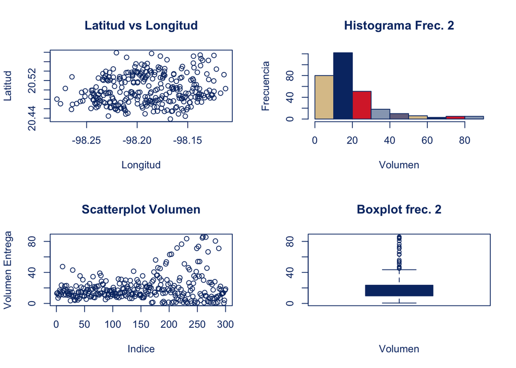

### In this case we have a smaller size of only three hundred, our median is fourteen and a half and smaller standard deviation than the one from frequency one, from the plot we could see that are more interpretable because our sample is of a smaller size, from the histogram we could see in a graphic way, the result of a bigger median and also from the scatterplot, the values are on the bottom but not as much as frequency one.

## Frequency = 3

```
## [1] "Size:"
## [1] 26
## [1] "Central tendency measures:"
##    Min. 1st Qu.  Median    Mean 3rd Qu.    Max.
##   6.333  10.417  14.667  14.423  17.667  26.000
## [1] "Standard deviation:"
```

```
## [1] 4.580692
```

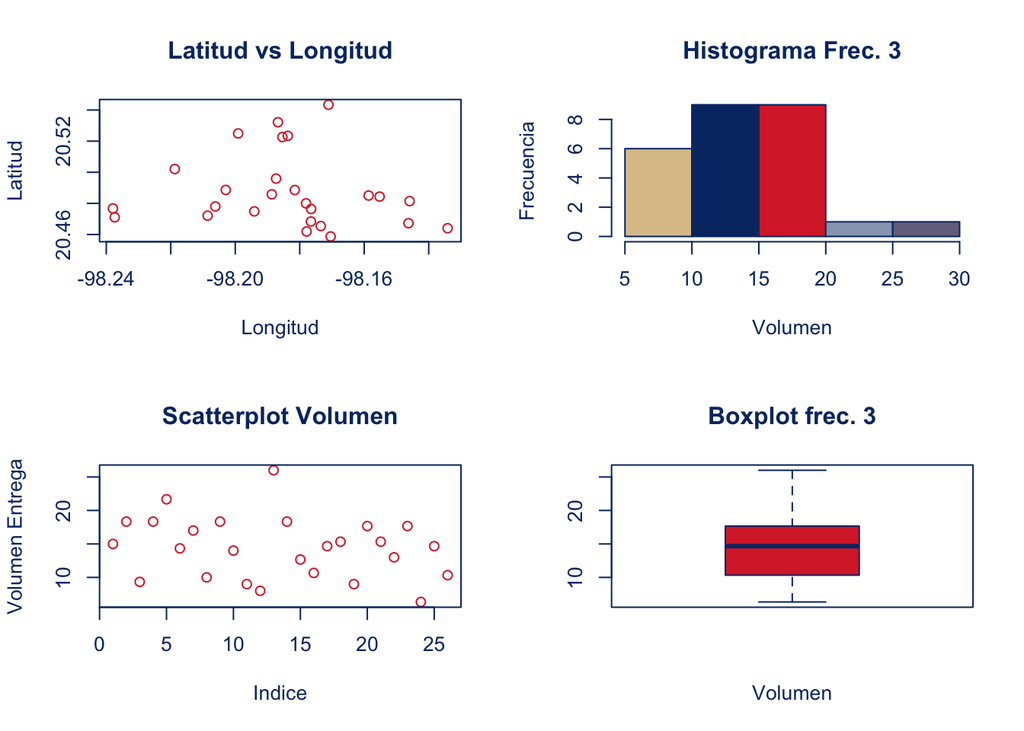

### Finally, we have the smallest sample of only twenty-six values, from the scatter plot we could see that most of our values are between ten and twenty, that’s why our median is 14.67, and this sample has a really small value of std compared to the other two, of only 4.58.

### Looking at the plots we could see that the values are dispersed but not so much, our range of values are really small, it’s confirmed with the boxplot that doesn’t have any outlier, and all the values are on the box or the arms.